# Who were the best Premier League Players by their positions

By Theodore Etuwewe & Usman Agboola

2025-11-10

## *Introduction*

The Premier League is a battlefield, and every player is fighting for glory. Because of this, we were inspired to find out who was truly number 1 in their positions. The analysis aims to dive into the stats that separate the stars from the rest; goals, assists, tackles, interceptions, clean sheets, and more. By looking at offensive firepower, defensive strength, and goalkeeping feats, we aim to crown the ultimate player of the season, the one who dominates all players of the game.

We got this dataset from Kaggle, and here’s a link to it: [English Premier League Player Stats](https://www.kaggle.com/datasets/rishikeshkanabar/premier-league-player-statistics-updated-daily)

But before we look into the data, lets clean it up a bit.

# *Cleaning Up process*

```r
premleague <- premleague %>%
  filter(!is.na(Name) & Name != "") %>%                       # removes rows with missing player name
  distinct()                                                  # removes duplicate rows

glimpse(premleague)
```

```
## Rows: 571
## Columns: 59
## $ Name                   <chr> "Bernd Leno", "Matt Macey", "Rúnar Alex Rúnarss…
## $ Jersey.Number          <int> 1, 33, 13, 2, 3, 4, 5, 16, 20, 21, 23, 31, 6, 1…
## $ Club                   <chr> "Arsenal", "Arsenal", "Arsenal", "Arsenal", "Ar…
## $ Position               <chr> "Goalkeeper", "Goalkeeper", "Goalkeeper", "Defe…
## $ Nationality            <chr> "Germany", "England", "Iceland", "Spain", "Scot…
## $ Age                    <int> 28, 26, 25, 25, 23, 19, 32, 25, 28, 25, 33, 27,…
## $ Appearances            <int> 64, 0, 0, 160, 16, 0, 44, 41, 99, 139, 194, 78,…
## $ Wins                   <int> 28, 0, 0, 90, 7, 0, 21, 25, 52, 47, 113, 40, 2,…
## $ Losses                 <int> 16, 0, 0, 37, 5, 0, 11, 9, 26, 57, 38, 22, 0, 3…
## $ Goals                  <int> 0, 0, 0, 7, 1, 0, 3, 0, 7, 6, 13, 2, 1, 33, 3, …
## $ Goals.per.match        <dbl> NA, NA, NA, NA, NA, NA, NA, NA, NA, NA, NA, NA,…
## $ Headed.goals           <int> NA, NA, NA, 0, 0, 0, 1, 0, 6, 1, 6, 0, 0, 4, 0,…
## $ Goals.with.right.foot  <int> NA, NA, NA, 4, 0, 0, 2, 0, 1, 4, 6, 0, 0, 4, 3,…
```

[output cut: 46 more lines]

As you can see, there is a lot to look at here. This dataset contains detailed statistics for Premier League players like their offensive metrics, defensive metrics, and goalkeeper-specific statistics. What makes it interesting is the depth of information for each player, allowing analysis of scoring efficiency, defensive performance, and overall contribution to the team. It enables comparisons between players across positions, highlighting strengths and patterns that are not obvious from simple totals, such as who is the most efficient scorer or the most influential defender.

# *What do we intend to learn from this data?*

# *Core question*

1. What four players would be the foundation of a “Dream Team” ?

# *Other questions*

1. Who scored the most goals?
2. Who provided the most assists?
3. Who contributes the most per appearance?
4. How does each position contribute to scoring goals or performing assists?
5. Does age affect a players involvement in goals or assists?
6. What percentage of a teams goals does each player contribute?

*Alright*. enough chitchat. I believe its time to get down and dirty with the details.

# *1.Who scored the most goals?*

If we are being honest, this is all everyone and I mean *YOU* and me care about. Sure ironclad defense raises praise, last minute saves turn heads and flow state passes test ones faith, but sadly, these things don’t bring home the win. Goals do. So lets find out who brings home the most bacon in the league.

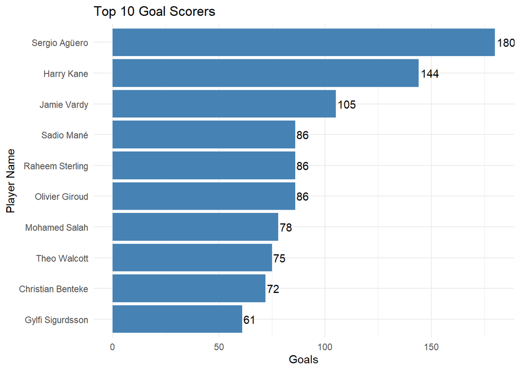

# *2. Who provided the most assists?*

Yes we all love scoring goals and celebrating afterwards but there is something that tends to be overlooked. These goals would not have happened if not for the effort of great midfielders. Here, we aim to find out who was the most influential midfielder, the man who made such wonderful goals possible.

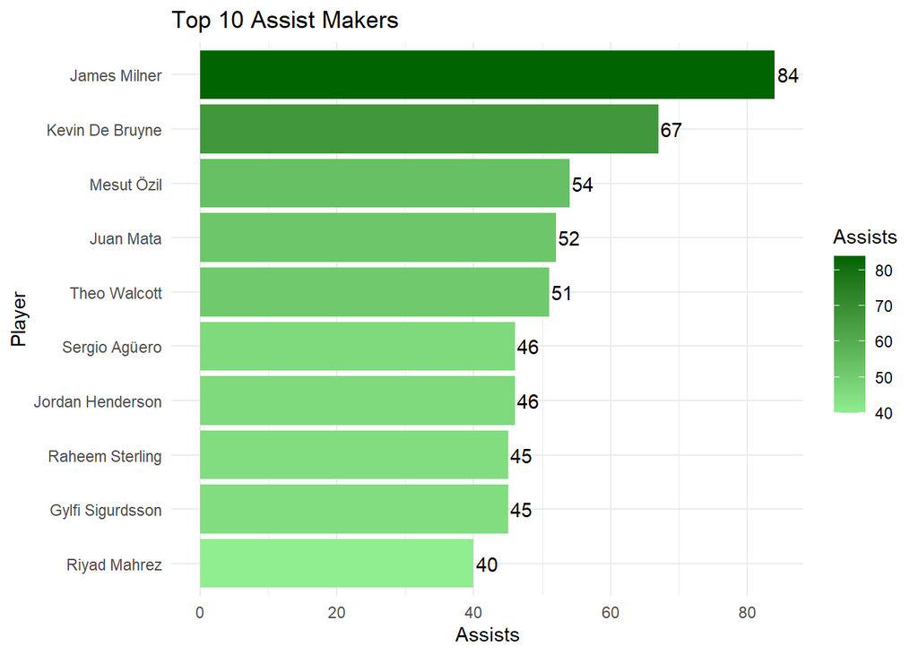

Turns out James Milner basically was the league’s assist wizard. The chart shows him handing out goals like party favors, his bar soars above everyone else, practically winking at the defenders. The gradient makes it official too. Darker green, bigger impact, more magic. The top 10 players are like a league of assist superheroes, but Milner is clearly the one wearing the cape, setting up teammates and making the pitch his personal playground.

# *3. Who contributes the most per appearance?*

This is all about efficiency, which players make the biggest impact every time they step on the pitch. To reach a conclusion, we created a “Goal Involvement” stat by adding goals and assists, then divided it by appearances to see who packs the most punch per game. Filtering out players with fewer than five appearances keeps the sample fair.

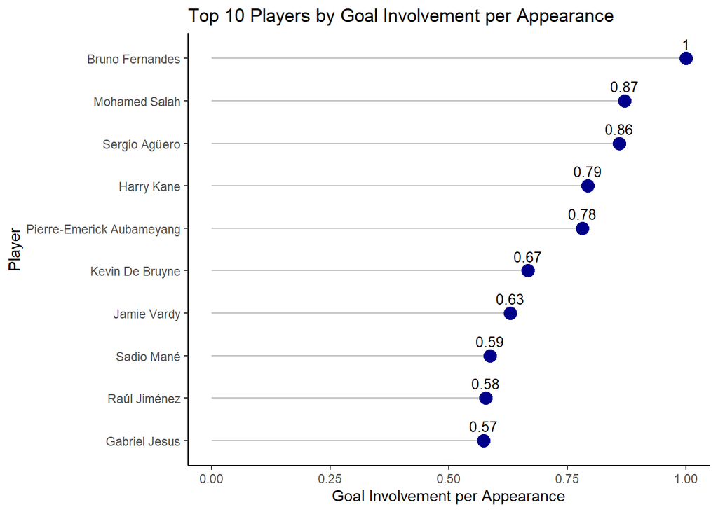

From the results, you can spot the real game changers. The players who aren’t just scoring or assisting occasionally, they’re delivering consistently every time they play. It’s like a cheat code for impact, the longer the line and the higher the dot, the more indispensable the player. Basically, these top 10 are the “per-appearance legends” of the league, showing who you want on your fantasy team if you care about efficiency over volume.

# *4. How does each position contribute to scoring goals or performing assists?*

These two boxplots give a clear picture of how goal involvement is distributed across different positions. The first plot shows the raw values, letting you see which positions naturally contribute the most. Forwards dominate the upper end, as expected, they’re the ones putting the ball in the net, while midfielders show a mix of assists and occasional goals. Defenders and goalkeepers cluster near the bottom, reflecting their limited attacking roles.

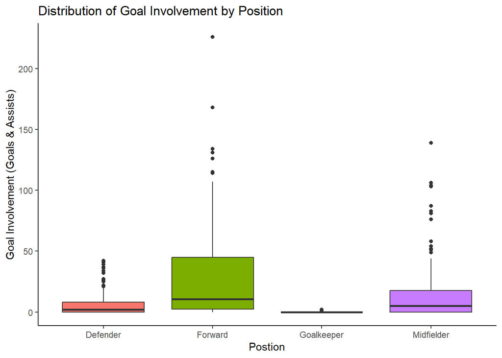

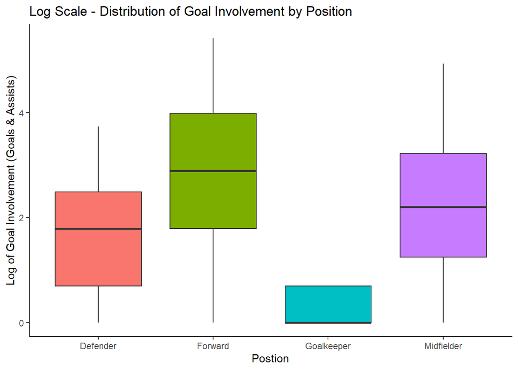

The second plot uses a log scale, which tames the extreme values and makes it easier to compare the spread across positions. It highlights variability in midfielders and forwards without being overshadowed by a few prolific scorers. This view shows that while most defenders and goalkeepers stay low, midfielders can have surprisingly high impact games, and forwards consistently reach the top.

# *5. Does age affect a players involvement in goals or assists?*

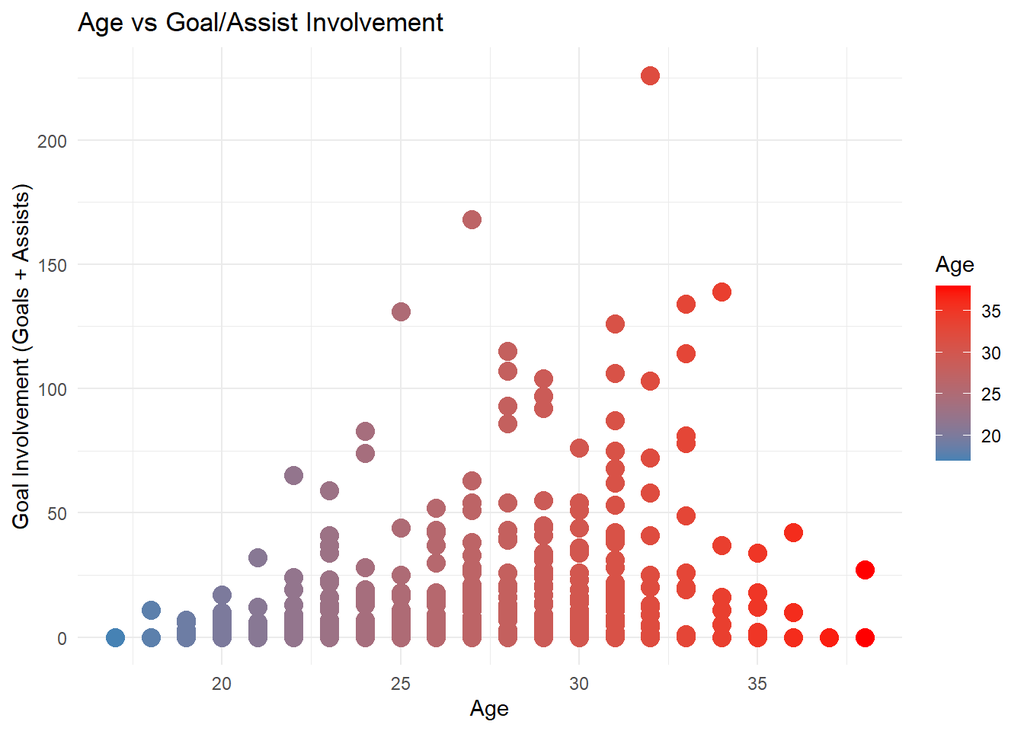

# *6. What percentage of a teams goals does each player contribute?*

Here, we dive into who really carries their team’s attack. First, we calculated each club’s total goals, then determined what percentage of that total each player scored. By arranging players from highest to lowest contribution and picking the top 15, we can see the true goal-getters.

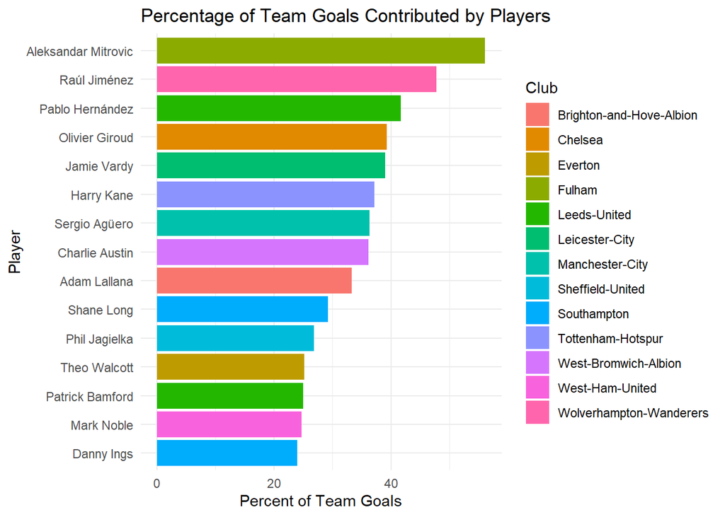

The results show that indeed there is an I in team. From the results, you can identify the players who are mission-critical for their squads, those who, if they don’t score, their team’s attack really struggles. This visualization turns raw goal counts into a perspective on influence and responsibility, showing who is the true heartbeat of their team’s offense.

Now, with all we’ve seen. It’s about time to ask the real question we all gathered here for.

# *What four players would you build a dream team around?*

To find out who the foundation of this team would be, I checked the real column names so I wasn’t guessing who had goals, tackles, or clean sheets. Then I picked one simple, fair metric for each position; goals for forwards, assists for midfielders, tackles for defenders, and clean sheets for goalkeepers. After that, I grouped players by position, grabbed the top performer in each group, and stitched the four winners into one neat “Dream Team” table. The result delivers one elite forward, one midfield engine, one defensive wall, and one keeper who refuses to let anything in. It’s like assembling the Avengers, but with shin guards.

Premier League Dream Team

| Name | Club | Position | Goals | Assists | Tackles | Clean.sheets |
| --- | --- | --- | --- | --- | --- | --- |
| Phil Bardsley | Burnley | Defender | 7 | 5 | 728 | 67 |
| Sergio Agüero | Manchester-City | Forward | 180 | 46 | 150 | NA |
| Joe Hart | Tottenham-Hotspur | Goalkeeper | 0 | 1 | NA | 127 |
| James Milner | Liverpool | Midfielder | 55 | 84 | 803 | NA |

The results have given us the core foundation for the powerhouse for a team. Based on these statistics, we were able to determine who was the best in their own aspects, from strong forwards and midfielders to masterclass goalkeepers and defenders, the stats show that these players are more than capable of out performing the rest and consistently bringing home the win.

# *Summary*

Overall, the analysis paints a full picture of the league’s offensive landscape, the prolific scorers, the creative engines, the consistent performers, and the indispensable stars. Putting it all together, and we’ve got a cast of Premier League legends, the creators, the finishers, the efficient machines, and the indispensable heroes. Perfect for spotting dream-team builders or just bragging about your favorite players’ impact.